# FML clustering assignment

the goal is to find a balance where clusters are tight internally (low within-cluster sum of squares) and distinct from each other (high among-cluster sum of squares). The choice of 3 clusters strikes a reasonable balance for this dataset based on the analysis of the sum of squares.

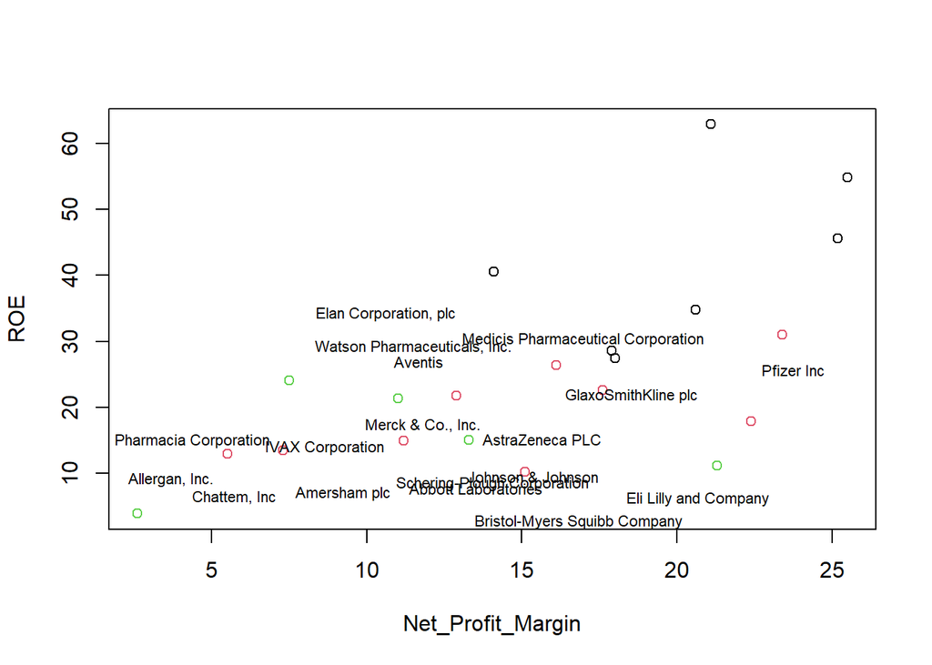

```r
plot(ROE~Net_Profit_Margin, df, col= kc$cluster)
with(df,text(df$Rev_Growth ~ df$Net_Profit_Margin, labels=df$Name,pos=2, cex=0.7))
```

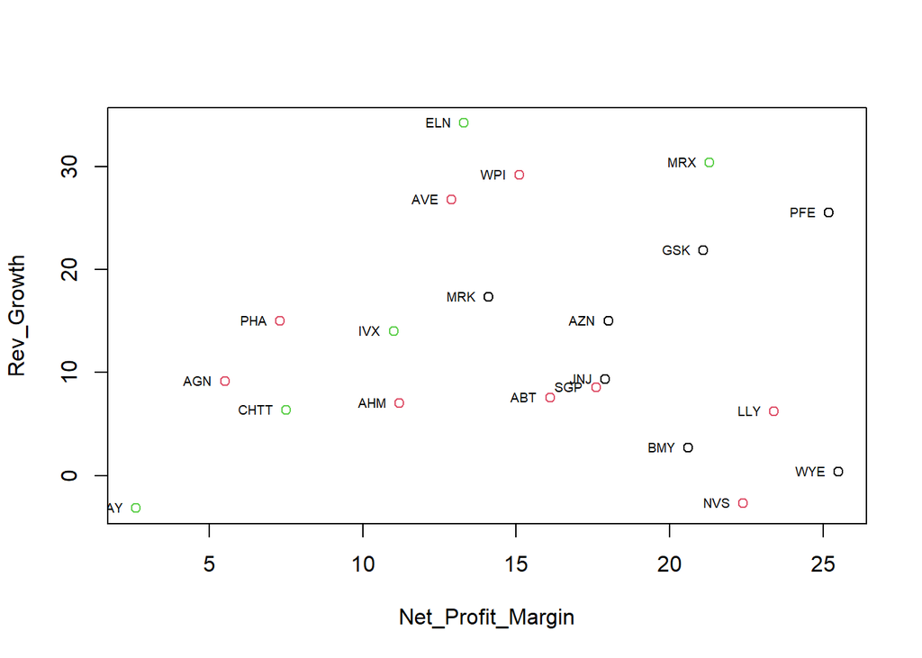

```r
plot(Rev_Growth~Net_Profit_Margin, df, col= kc$cluster)
with(df,text(df$Rev_Growth ~ df$Net_Profit_Margin, labels=df$Symbol,pos=2, cex=0.6))
```

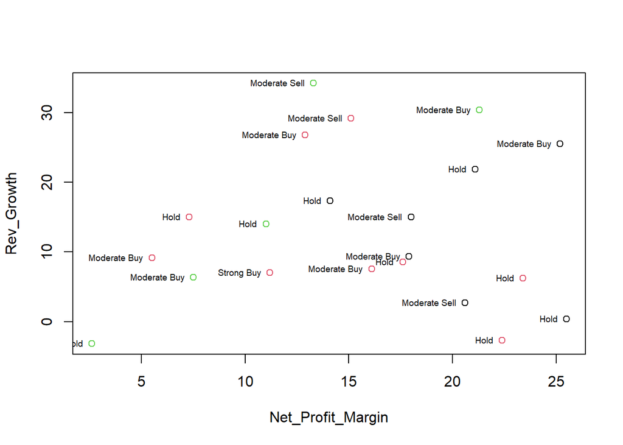

```r
plot(Rev_Growth~Net_Profit_Margin, df, col= kc$cluster)
with(df,text(df$Rev_Growth ~ df$Net_Profit_Margin, labels=df$Median_Recommendation,pos=2, cex=0.6))
```

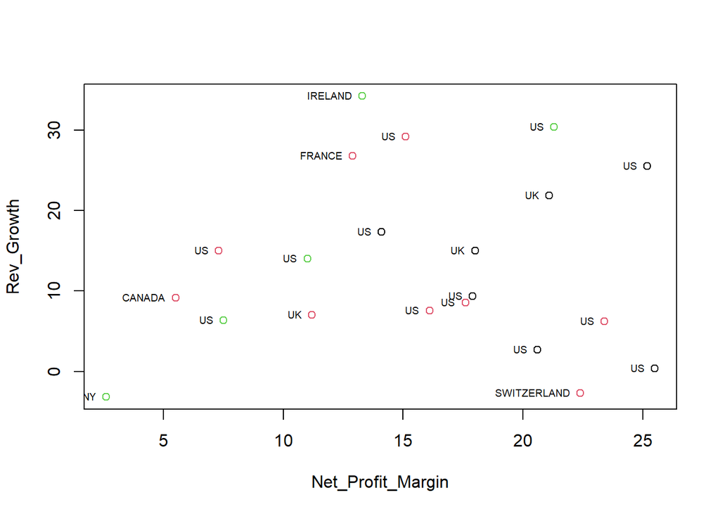

```r
plot(Rev_Growth~Net_Profit_Margin, df, col= kc$cluster)
with(df,text(df$Rev_Growth ~ df$Net_Profit_Margin, labels=df$Location,pos=2, cex=0.6))
```

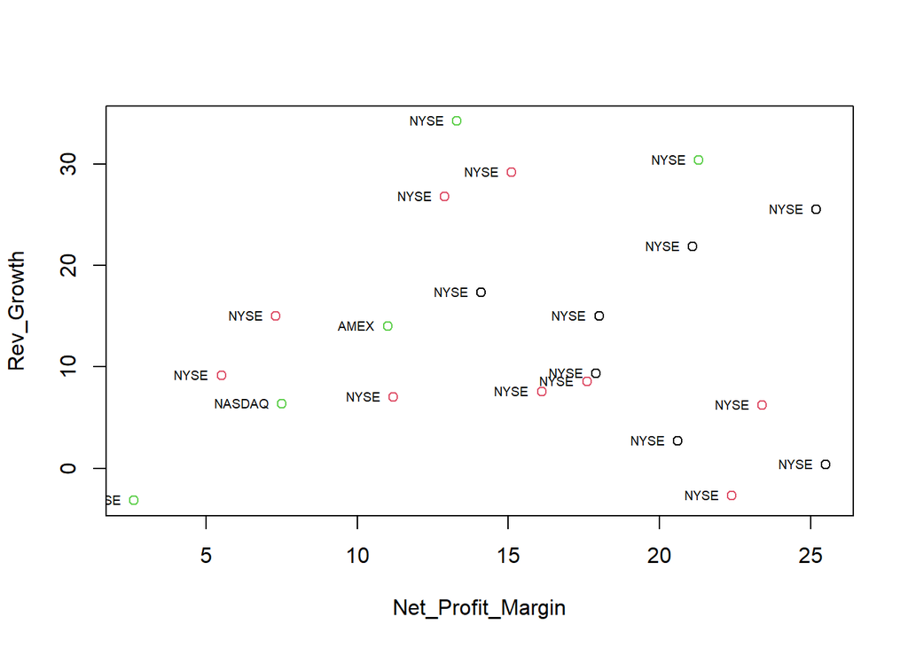

```r
plot(Rev_Growth~Net_Profit_Margin, df, col= kc$cluster)
with(df,text(df$Rev_Growth ~ df$Net_Profit_Margin, labels=df$Exchange,pos=2, cex=0.6))
```

```r
# Load necessary libraries
library(factoextra)
```

```
##   cluster size ave.sil.width
## 1       1    7          0.26
## 2       2    9          0.16
## 3       3    5          0.11
```

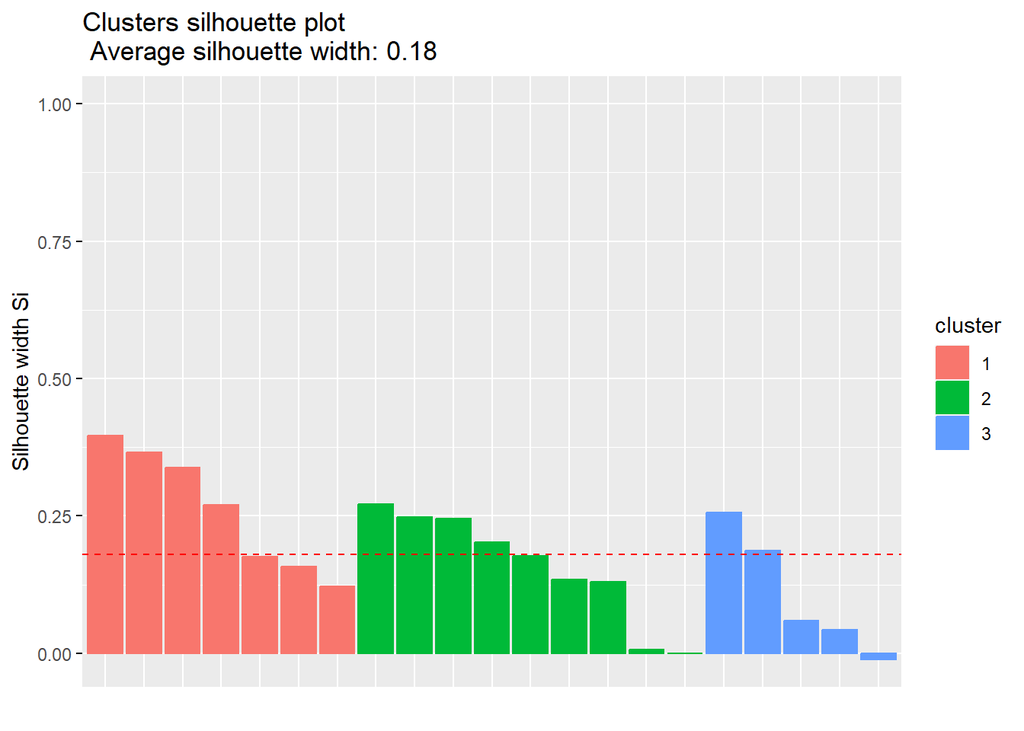

```r
library(cluster)
# Create a silhouette object
silhouette_kmeans <- silhouette(kc$cluster, dist(df_scale))  # Calculate distances using 'dist' function

# Plot the silhouette
fviz_silhouette(silhouette_kmeans)
```

I have compared the silhouette score for both methods and its higher in the hierarchical agglomerative clustering with complete linkage when compare to k means. IN the hierarchical agglomerative clustering with complete linkage its is 0.27 and in k means its 0.18 so the objects in the hierarchical clustering result are better matched to their own clusters than those in the K-means clustering . So clusters that were formed by hierarchical agglomerative clustering using complete linkage is more distinct or well-separated compared to the clusters formed by K-means . So I decide to choose hierarchical agglomerative clustering with complete linkage for my clustering analysis. To better understand the above point look at the silhouette plot.

```
##   cluster size ave.sil.width
## 1       1    7          0.26
## 2       2    9          0.16
## 3       3    5          0.11
```

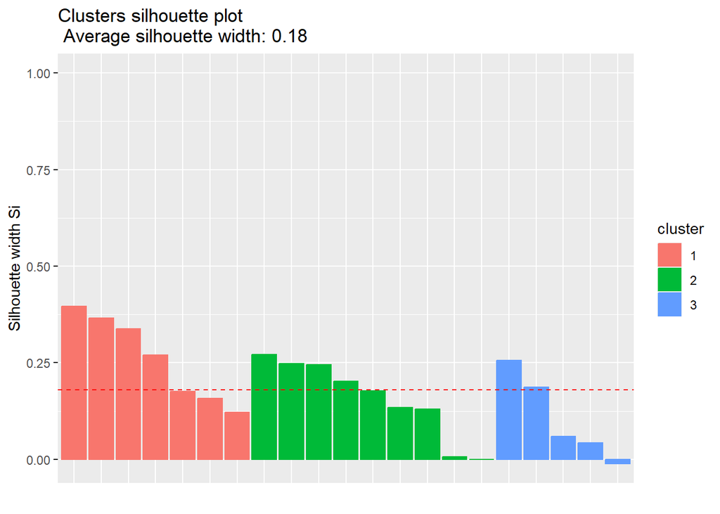

```r
# Plot both silhouettes side by side
par(mfrow=c(1, 2))  # Set the layout to display plots side by side

# Plot the silhouette for K-means
fviz_silhouette(silhouette_kmeans)
```

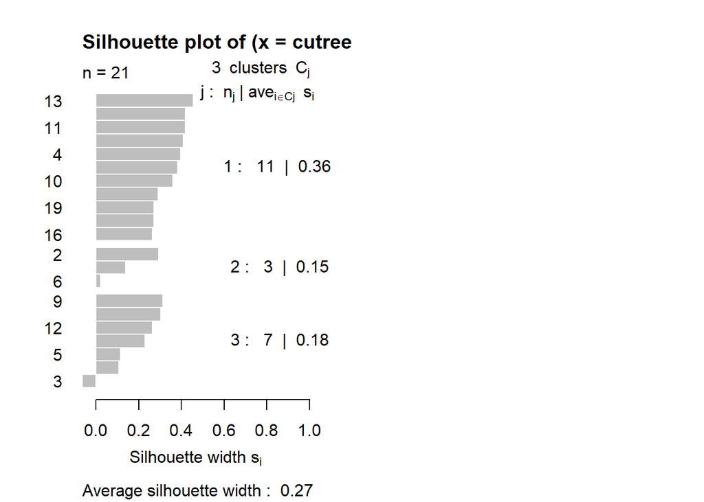

```r
# Silhouette Plot for Hierarchical Clustering
plot(silhouette(cutree(hc.c,3), distance))
```

```r
# Cluster memberships for each method
hc_c_clusters <- cutree(hc.c, 3)
hc_a_clusters <- cutree(hc_a, 3)
kc_clusters <- kc$cluster
```

```r
# Columns to analyze
selected_columns <- c('Median_Recommendation', 'Location', 'Exchange')

# Subset categorical columns along with cluster memberships
cluster_data <- cbind(
  df[selected_columns],
  hc_c = hc_c_clusters,
  hc_a = hc_a_clusters,
  kc = kc_clusters
)
```

```r
# Analyzing 'Median_Recommendation', 'Location', and 'Exchange' within clusters
for (method in c('hc_c', 'hc_a', 'kc')) {
  cat("\nCluster analysis for method:", method, "\n")
  for (col in selected_columns) {
    cat("Variable:", col, "\n")
    table_result <- table(cluster_data[[method]], cluster_data[[col]])
    print(table_result)
    # Optionally, perform chi-square tests here
    # chi_result <- chisq.test(table_result)
    # print(chi_result)
  }
}
```

```
##
## Cluster analysis for method: hc_c
## Variable: Median_Recommendation
##
##     Hold Moderate Buy Moderate Sell Strong Buy
##   1    6            3             2          0
##   2    2            1             0          0
##   3    1            3             2          1
## Variable: Location
##
##     CANADA FRANCE GERMANY IRELAND SWITZERLAND UK US
##   1      0      0       0       0           1  2  8
##   2      1      0       1       0           0  0  1
##   3      0      1       0       1           0  1  4
## Variable: Exchange
##
##     AMEX NASDAQ NYSE
##   1    0      0   11
##   2    0      0    3
##   3    1      1    5
##
## Cluster analysis for method: hc_a
## Variable: Median_Recommendation
##
##     Hold Moderate Buy Moderate Sell Strong Buy
##   1    7            4             3          1
##   2    2            1             0          0
##   3    0            2             1          0
## Variable: Location
##
##     CANADA FRANCE GERMANY IRELAND SWITZERLAND UK US
##   1      0      1       0       0           1  3 10
##   2      1      0       1       0           0  0  1
##   3      0      0       0       1           0  0  2
## Variable: Exchange
##
##     AMEX NASDAQ NYSE
##   1    1      0   14
##   2    0      0    3
##   3    0      1    2
##
## Cluster analysis for method: kc
## Variable: Median_Recommendation
##
##     Hold Moderate Buy Moderate Sell Strong Buy
##   1    3            2             2          0
##   2    4            3             1          1
##   3    2            2             1          0
## Variable: Location
##
##     CANADA FRANCE GERMANY IRELAND SWITZERLAND UK US
##   1      0      0       0       0           0  2  5
##   2      1      1       0       0           1  1  5
##   3      0      0       1       1           0  0  3
## Variable: Exchange
##
##     AMEX NASDAQ NYSE
##   1    0      0    7
##   2    0      0    9
##   3    1      1    3
```

There is some clear patterns and similarities across clusters within each method:

Across Hierarchical Clustering (hc_c):

Cluster 1: Dominated by ‘Hold’ recommendations and ‘NYSE’ exchanges, mostly from the US. Cluster 2: Quite distinct, with less variability in recommendations and locations but still heavily tied to ‘NYSE’. Cluster 3: A mix of various recommendations, more varied locations, but still heavily associated with ‘NYSE’.

Across K-means Clustering (kc): Cluster 1: ‘Hold’ is dominant, locations are primarily in the US, and ‘NYSE’ is the preferred exchange. Cluster 2: Similar to Cluster 1 in terms of recommendation and exchange preference, still mostly from the US. Cluster 3: A mix of ‘Hold’ and ‘Moderate Buy’, primarily from the US, and again favoring ‘NYSE’.

#How the above information helps equities analyst studying the pharmaceutical industry? This information can be particularly insightful for an equities analyst studying the pharmaceutical industry in several ways:

Investment Strategies: Understanding Market Trends: Recurrent trends like ‘Hold’ recommendations and prevalence on ‘NYSE’ might indicate stability or common investor sentiment across clusters. This insight can guide decisions on long-term investments or cautious strategies.

Regional Focus: Dominance of the US in location might emphasize the concentration of pharmaceutical companies or key players in specific regions. It signals where significant market activity or potential growth might occur.

Risk Assessment: Risk Diversification: While ‘Hold’ recommendations suggest a certain level of stability, an equities analyst can delve deeper into other clusters with varied recommendations to diversify risk. Understanding the risk-reward ratio across different clusters aids in decision-making.

Industry Insights: Comparative Analysis: By observing how different clusters and preferences overlap or diverge across methodologies, analysts can gain a comparative view of how different investment strategies or clusters align within the pharmaceutical industry.

Investment Allocation: Portfolio Distribution: Insights into recurring patterns can help balance investment portfolios across clusters, optimizing for stability, growth, and potential.

Strategy Adaptation: Adapting to Market Sentiment: Recognizing recurrent preferences enables analysts to adapt their strategies based on evolving market sentiments, allowing for proactive investment decisions.

Risk Mitigation: Identifying Outliers: Recognizing outliers within clusters or patterns diverging from the norm helps identify potential risks or unique opportunities. In essence, this information offers crucial guidance for investment strategies, risk assessment, industry insights, and adapting to market sentiments within the pharmaceutical industry. It allows for informed decision-making .

Considering the patterns and dominant characteristics observed across the clusters from the analysis of the pharmaceutical industry data:

1. **Cluster Stability and Reliability**
   - *Key Characteristics*: Dominance of ‘Hold’ recommendations, high presence on ‘NYSE’, and significant US presence in location.
   - *Rationale*: Reflects stability, consistent performance, and a strong market presence.
2. **Global Consistency Cluster**
   - *Key Characteristics*: Consistent ‘Hold’ recommendations, dominance of ‘NYSE’, and a strong US presence alongside international diversity.
   - *Rationale*: Represents stability with a global footprint, balancing US market influence with international opportunities.
3. **Dynamic Investment Diversity**
   - *Key Characteristics*: Varied recommendations (‘Hold’, ‘Moderate Buy’), significant ‘NYSE’ presence, and a strong US market presence across clusters.
   - *Rationale*: Indicates a mix of cautious investment (Hold), moderate risk-taking (Moderate Buy), and a consistent market interest in the US.

These cluster names aim to capture the overarching characteristics observed across the different clustering methodologies and offer insight into the underlying investment trends, regional influences, and risk profiles within the pharmaceutical industry.